# Day 3

## 3.4 - Assignment 4: Network model

- Go through the code and see if you understand it.
- Can you tell where the 3 networks described above are located in the VAR output?
- Do you see a difference between the results of the network and the VAR model?

Also the results for this model are already stored in the R workspace (`LongNet`). The code is:

```r
# Network model
LongNet <- mlVAR(VARData[, c(1:3)], vars = c("Y1", "Y2"),
                 idvar = c("individual"),
                 lags = 1, temporal = "correlated")
```

```r
summary(LongNet)
```

```
mlVAR estimation completed. Input was:
    - Variables: Y1 Y2
    - Lags: 1
    - Estimator: lmer
    - Temporal: correlated

Information indices:
 var      aic      bic
  Y1 11502.36 11573.82
  Y2 11187.78 11259.25


Temporal effects:
 from to lag fixed    SE P ran_SD
   Y1 Y1   1 0.377 0.015 0  0.067
   Y1 Y2   1 0.188 0.016 0  0.095
   Y2 Y1   1 0.111 0.015 0  0.067
   Y2 Y2   1 0.276 0.017 0  0.104


Contemporaneous effects (posthoc estimated):
 v1 v2 P 1->2 P 1<-2  pcor ran_SD_pcor   cor ran_SD_cor
 Y2 Y1      0      0 0.298       0.018 0.298      0.018


Between-subject effects:
 v1 v2 P 1->2 P 1<-2  pcor   cor
 Y2 Y1      0      0 0.408 0.408
```

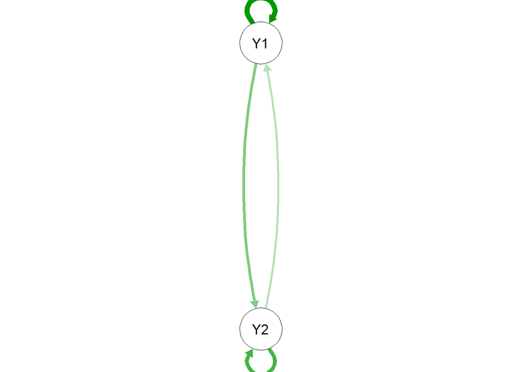

```r
plot(LongNet)
```

```r
# Recall the VAR model
summary(VAR)
```

```
 Family: MV(gaussian, gaussian)
  Links: mu = identity; sigma = identity
         mu = identity; sigma = identity
Formula: Y1 ~ Y1lag_c + Y2lag_c + (1 | p | individual)
         Y2 ~ Y1lag_c + Y2lag_c + (1 | p | individual)
   Data: VARData (Number of observations: 4900)
  Draws: 2 chains, each with iter = 5000; warmup = 2500; thin = 1;
         total post-warmup draws = 5000

Group-Level Effects:
~individual (Number of levels: 100)
                               Estimate Est.Error l-95% CI u-95% CI Rhat Bulk_ESS Tail_ESS
sd(Y1_Intercept)                   0.56      0.04     0.48     0.65 1.01     1068     1499
sd(Y2_Intercept)                   0.54      0.04     0.47     0.63 1.00     1230     1816
cor(Y1_Intercept,Y2_Intercept)     0.37      0.09     0.18     0.53 1.00     1134     1971

Population-Level Effects:
             Estimate Est.Error l-95% CI u-95% CI Rhat Bulk_ESS Tail_ESS
Y1_Intercept     3.96      0.06     3.85     4.07 1.00      733     1312
Y2_Intercept     4.36      0.06     4.24     4.47 1.00      911     1570
Y1_Y1lag_c       0.39      0.01     0.36     0.42 1.00     7922     4246
Y1_Y2lag_c       0.10      0.01     0.08     0.13 1.00     7330     3847
Y2_Y1lag_c       0.20      0.01     0.17     0.23 1.00     7991     3941
Y2_Y2lag_c       0.30      0.01     0.27     0.32 1.00     8047     4258

Family Specific Parameters:
         Estimate Est.Error l-95% CI u-95% CI Rhat Bulk_ESS Tail_ESS
sigma_Y1     1.01      0.01     0.99     1.03 1.00     7562     3696
sigma_Y2     1.04      0.01     1.02     1.06 1.00     8627     3650

Residual Correlations:
              Estimate Est.Error l-95% CI u-95% CI Rhat Bulk_ESS Tail_ESS
rescor(Y1,Y2)     0.29      0.01     0.26     0.31 1.00     8999     4234

Draws were sampled using sampling(NUTS). For each parameter, Bulk_ESS
and Tail_ESS are effective sample size measures, and Rhat is the potential
scale reduction factor on split chains (at convergence, Rhat = 1).
```

The Temporal effects are the lagged effect; the contemporaneous network is the correlation between residuals; the between network is the correlation between intercepts/means.

Final remark on VAR modeling vs. the network approach: The VAR model has some benefits over the network approach since it uses true multilevel analysis, and the parameters are easier to interpret (i.e., we get information on ‘significance’ etc.), but it scales less nicely to larger sample sizes and larger number of variables (although there are ways around that). Networks also have nicer visualization out of the box. Which method you choose again comes down to modeling the same data in slightly different (but highly similar) ways, and which methods is best depends on you research question etc. Even if you go for a VAR model though, networks are always a good place to start because of their nice visualization of the data (in ways relevant to VAR models).